# Risk Factor Analysis

## Outcome Variable

**Outcome Variable:** sstunted

## Predictor Variables

**Intervention Variable:** mhtcm

**Adjustment Set:**

unadjusted

## Stratifying Variables

The analysis was stratified on these variable(s):

- agecat
- studyid
- country

## Data Summary

| agecat | studyid | country | mhtcm | sstunted | n_cell | n |
| --- | --- | --- | --- | --- | --- | --- |
| Birth | ki0047075b-MAL-ED | BANGLADESH | >=155 cm | 0 | 21 | 222 |
| Birth | ki0047075b-MAL-ED | BANGLADESH | >=155 cm | 1 | 1 | 222 |
| Birth | ki0047075b-MAL-ED | BANGLADESH | <151 cm | 0 | 139 | 222 |
| Birth | ki0047075b-MAL-ED | BANGLADESH | <151 cm | 1 | 6 | 222 |
| Birth | ki0047075b-MAL-ED | BANGLADESH | [151-155) cm | 0 | 55 | 222 |
| Birth | ki0047075b-MAL-ED | BANGLADESH | [151-155) cm | 1 | 0 | 222 |
| Birth | ki0047075b-MAL-ED | BRAZIL | >=155 cm | 0 | 32 | 64 |
| Birth | ki0047075b-MAL-ED | BRAZIL | >=155 cm | 1 | 0 | 64 |
| Birth | ki0047075b-MAL-ED | BRAZIL | <151 cm | 0 | 19 | 64 |
| Birth | ki0047075b-MAL-ED | BRAZIL | <151 cm | 1 | 1 | 64 |
| Birth | ki0047075b-MAL-ED | BRAZIL | [151-155) cm | 0 | 10 | 64 |
| Birth | ki0047075b-MAL-ED | BRAZIL | [151-155) cm | 1 | 2 | 64 |
| Birth | ki0047075b-MAL-ED | INDIA | >=155 cm | 0 | 11 | 43 |
| Birth | ki0047075b-MAL-ED | INDIA | >=155 cm | 1 | 1 | 43 |
| Birth | ki0047075b-MAL-ED | INDIA | <151 cm | 0 | 19 | 43 |
| Birth | ki0047075b-MAL-ED | INDIA | <151 cm | 1 | 1 | 43 |
| Birth | ki0047075b-MAL-ED | INDIA | [151-155) cm | 0 | 11 | 43 |
| Birth | ki0047075b-MAL-ED | INDIA | [151-155) cm | 1 | 0 | 43 |
| Birth | ki0047075b-MAL-ED | NEPAL | >=155 cm | 0 | 6 | 27 |
| Birth | ki0047075b-MAL-ED | NEPAL | >=155 cm | 1 | 0 | 27 |
| Birth | ki0047075b-MAL-ED | NEPAL | <151 cm | 0 | 13 | 27 |
| Birth | ki0047075b-MAL-ED | NEPAL | <151 cm | 1 | 0 | 27 |
| Birth | ki0047075b-MAL-ED | NEPAL | [151-155) cm | 0 | 7 | 27 |
| Birth | ki0047075b-MAL-ED | NEPAL | [151-155) cm | 1 | 1 | 27 |
| Birth | ki0047075b-MAL-ED | PERU | >=155 cm | 0 | 48 | 226 |
| Birth | ki0047075b-MAL-ED | PERU | >=155 cm | 1 | 0 | 226 |
| Birth | ki0047075b-MAL-ED | PERU | <151 cm | 0 | 127 | 226 |
| Birth | ki0047075b-MAL-ED | PERU | <151 cm | 1 | 4 | 226 |
| Birth | ki0047075b-MAL-ED | PERU | [151-155) cm | 0 | 47 | 226 |
| Birth | ki0047075b-MAL-ED | PERU | [151-155) cm | 1 | 0 | 226 |

[output cut: 324 more lines]

The following strata were considered:

- agecat: 24 months, studyid: ki0047075b-MAL-ED, country: BANGLADESH
- agecat: 24 months, studyid: ki0047075b-MAL-ED, country: BRAZIL
- agecat: 24 months, studyid: ki0047075b-MAL-ED, country: INDIA
- agecat: 24 months, studyid: ki0047075b-MAL-ED, country: NEPAL
- agecat: 24 months, studyid: ki0047075b-MAL-ED, country: PERU
- agecat: 24 months, studyid: ki0047075b-MAL-ED, country: SOUTH AFRICA
- agecat: 24 months, studyid: ki0047075b-MAL-ED, country: TANZANIA, UNITED REPUBLIC OF
- agecat: 24 months, studyid: ki1017093-NIH-Birth, country: BANGLADESH
- agecat: 24 months, studyid: ki1017093b-PROVIDE, country: BANGLADESH
- agecat: 24 months, studyid: ki1017093c-NIH-Crypto, country: BANGLADESH
- agecat: 24 months, studyid: ki1066203-TanzaniaChild2, country: TANZANIA, UNITED REPUBLIC OF
- agecat: 24 months, studyid: ki1101329-Keneba, country: GAMBIA
- agecat: 24 months, studyid: ki1119695-PROBIT, country: BELARUS
- agecat: 24 months, studyid: ki1126311-ZVITAMBO, country: ZIMBABWE
- agecat: 24 months, studyid: ki1135781-COHORTS, country: GUATEMALA
- agecat: 24 months, studyid: ki1135781-COHORTS, country: INDIA
- agecat: 24 months, studyid: ki1135781-COHORTS, country: PHILIPPINES
- agecat: 24 months, studyid: ki1148112-LCNI-5, country: MALAWI
- agecat: 24 months, studyid: kiGH5241-JiVitA-3, country: BANGLADESH
- agecat: 6 months, studyid: ki0047075b-MAL-ED, country: BANGLADESH
- agecat: 6 months, studyid: ki0047075b-MAL-ED, country: BRAZIL
- agecat: 6 months, studyid: ki0047075b-MAL-ED, country: INDIA
- agecat: 6 months, studyid: ki0047075b-MAL-ED, country: NEPAL
- agecat: 6 months, studyid: ki0047075b-MAL-ED, country: PERU
- agecat: 6 months, studyid: ki0047075b-MAL-ED, country: SOUTH AFRICA
- agecat: 6 months, studyid: ki0047075b-MAL-ED, country: TANZANIA, UNITED REPUBLIC OF
- agecat: 6 months, studyid: ki1000304b-SAS-CompFeed, country: INDIA
- agecat: 6 months, studyid: ki1000304b-SAS-FoodSuppl, country: INDIA
- agecat: 6 months, studyid: ki1017093-NIH-Birth, country: BANGLADESH
- agecat: 6 months, studyid: ki1017093b-PROVIDE, country: BANGLADESH
- agecat: 6 months, studyid: ki1017093c-NIH-Crypto, country: BANGLADESH
- agecat: 6 months, studyid: ki1066203-TanzaniaChild2, country: TANZANIA, UNITED REPUBLIC OF
- agecat: 6 months, studyid: ki1101329-Keneba, country: GAMBIA
- agecat: 6 months, studyid: ki1112895-Guatemala BSC, country: GUATEMALA
- agecat: 6 months, studyid: ki1119695-PROBIT, country: BELARUS
- agecat: 6 months, studyid: ki1126311-ZVITAMBO, country: ZIMBABWE
- agecat: 6 months, studyid: ki1135781-COHORTS, country: GUATEMALA
- agecat: 6 months, studyid: ki1135781-COHORTS, country: INDIA
- agecat: 6 months, studyid: ki1135781-COHORTS, country: PHILIPPINES
- agecat: 6 months, studyid: ki1148112-LCNI-5, country: MALAWI
- agecat: 6 months, studyid: kiGH5241-JiVitA-3, country: BANGLADESH
- agecat: Birth, studyid: ki0047075b-MAL-ED, country: BANGLADESH
- agecat: Birth, studyid: ki0047075b-MAL-ED, country: BRAZIL
- agecat: Birth, studyid: ki0047075b-MAL-ED, country: INDIA
- agecat: Birth, studyid: ki0047075b-MAL-ED, country: NEPAL
- agecat: Birth, studyid: ki0047075b-MAL-ED, country: PERU
- agecat: Birth, studyid: ki0047075b-MAL-ED, country: SOUTH AFRICA
- agecat: Birth, studyid: ki0047075b-MAL-ED, country: TANZANIA, UNITED REPUBLIC OF
- agecat: Birth, studyid: ki1000304b-SAS-CompFeed, country: INDIA
- agecat: Birth, studyid: ki1017093-NIH-Birth, country: BANGLADESH
- agecat: Birth, studyid: ki1017093b-PROVIDE, country: BANGLADESH
- agecat: Birth, studyid: ki1017093c-NIH-Crypto, country: BANGLADESH
- agecat: Birth, studyid: ki1101329-Keneba, country: GAMBIA
- agecat: Birth, studyid: ki1119695-PROBIT, country: BELARUS
- agecat: Birth, studyid: ki1126311-ZVITAMBO, country: ZIMBABWE
- agecat: Birth, studyid: ki1135781-COHORTS, country: GUATEMALA
- agecat: Birth, studyid: ki1135781-COHORTS, country: INDIA
- agecat: Birth, studyid: ki1135781-COHORTS, country: PHILIPPINES
- agecat: Birth, studyid: kiGH5241-JiVitA-3, country: BANGLADESH

### Dropped Strata

Some strata were dropped due to rare outcomes:

- agecat: Birth, studyid: ki0047075b-MAL-ED, country: BANGLADESH
- agecat: Birth, studyid: ki0047075b-MAL-ED, country: BRAZIL
- agecat: Birth, studyid: ki0047075b-MAL-ED, country: INDIA
- agecat: Birth, studyid: ki0047075b-MAL-ED, country: NEPAL
- agecat: Birth, studyid: ki0047075b-MAL-ED, country: PERU
- agecat: Birth, studyid: ki0047075b-MAL-ED, country: SOUTH AFRICA
- agecat: Birth, studyid: ki0047075b-MAL-ED, country: TANZANIA, UNITED REPUBLIC OF
- agecat: Birth, studyid: ki1017093-NIH-Birth, country: BANGLADESH
- agecat: Birth, studyid: ki1017093b-PROVIDE, country: BANGLADESH
- agecat: Birth, studyid: ki1017093c-NIH-Crypto, country: BANGLADESH
- agecat: Birth, studyid: ki1101329-Keneba, country: GAMBIA
- agecat: Birth, studyid: ki1119695-PROBIT, country: BELARUS
- agecat: Birth, studyid: ki1135781-COHORTS, country: GUATEMALA
- agecat: Birth, studyid: ki1135781-COHORTS, country: PHILIPPINES
- agecat: 6 months, studyid: ki0047075b-MAL-ED, country: BANGLADESH
- agecat: 6 months, studyid: ki0047075b-MAL-ED, country: BRAZIL
- agecat: 6 months, studyid: ki0047075b-MAL-ED, country: INDIA
- agecat: 6 months, studyid: ki0047075b-MAL-ED, country: NEPAL
- agecat: 6 months, studyid: ki0047075b-MAL-ED, country: PERU
- agecat: 6 months, studyid: ki0047075b-MAL-ED, country: SOUTH AFRICA
- agecat: 6 months, studyid: ki0047075b-MAL-ED, country: TANZANIA, UNITED REPUBLIC OF
- agecat: 6 months, studyid: ki1000304b-SAS-FoodSuppl, country: INDIA
- agecat: 6 months, studyid: ki1017093-NIH-Birth, country: BANGLADESH
- agecat: 6 months, studyid: ki1017093b-PROVIDE, country: BANGLADESH
- agecat: 6 months, studyid: ki1017093c-NIH-Crypto, country: BANGLADESH
- agecat: 6 months, studyid: ki1112895-Guatemala BSC, country: GUATEMALA
- agecat: 24 months, studyid: ki0047075b-MAL-ED, country: BANGLADESH
- agecat: 24 months, studyid: ki0047075b-MAL-ED, country: BRAZIL
- agecat: 24 months, studyid: ki0047075b-MAL-ED, country: INDIA
- agecat: 24 months, studyid: ki0047075b-MAL-ED, country: NEPAL
- agecat: 24 months, studyid: ki0047075b-MAL-ED, country: PERU
- agecat: 24 months, studyid: ki0047075b-MAL-ED, country: SOUTH AFRICA
- agecat: 24 months, studyid: ki1017093b-PROVIDE, country: BANGLADESH
- agecat: 24 months, studyid: ki1017093c-NIH-Crypto, country: BANGLADESH
- agecat: 24 months, studyid: ki1066203-TanzaniaChild2, country: TANZANIA, UNITED REPUBLIC OF
- agecat: 24 months, studyid: ki1119695-PROBIT, country: BELARUS

## Methods Detail

We’re interested in the causal parameters $E[Y_a]$ for all values of $a \in \mathcal{A}$. These parameters represent the mean outcome if, possibly contrary to fact, we intervened to set all units to have $A=a$. Under the randomization and positivity assumptions, these are identified by the statistical parameters $\psi_a=E_W[E_{Y|A,W}(Y|A=a,W)]$. In addition, we’re interested in the mean of $Y$, $E[Y]$ under no intervention (the observed mean). We will estimate these parameters by using SuperLearner to fit the relevant likelihood factors – $E_{Y|A,W}(Y|A=a,W)$ and $p(A=a|W)$, and then updating our likelihood fit using a joint TMLE.

For unadjusted analyses ($W=\{\}$), initial likelihoods were estimated using Lrnr_glm to estimate the simple $E(Y|A)$ and Lrnr_mean to estimate $p(A)$. For adjusted analyses, a small library containing Lrnr_glmnet, Lrnr_xgboost, and Lrnr_mean was used.

Having estimated these parameters, we will then use the delta method to estimate relative risks and attributable risks relative to a prespecified baseline level of $A$.

# Results Detail

## Results Plots

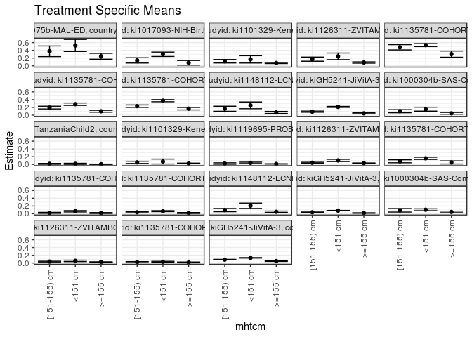

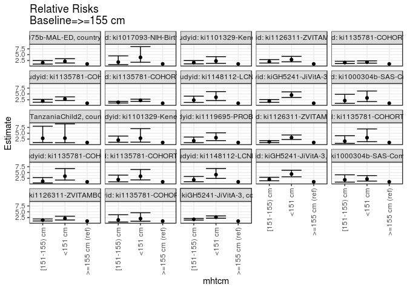

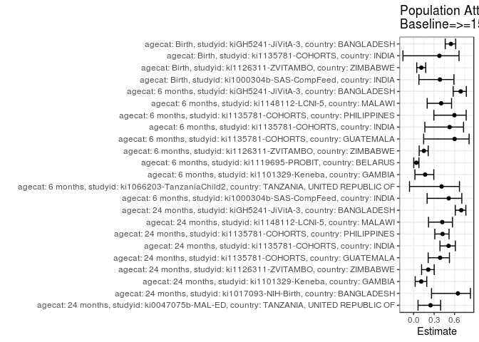

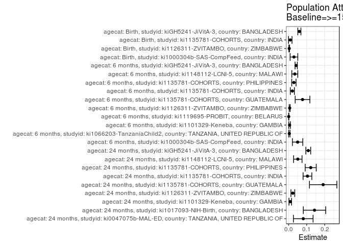

## Results Table

### Parameter: TSM

| agecat | studyid | country | intervention_level | baseline_level | estimate | ci_lower | ci_upper |
| --- | --- | --- | --- | --- | --- | --- | --- |
| Birth | ki1000304b-SAS-CompFeed | INDIA | >=155 cm | NA | 0.0471092 | 0.0266615 | 0.0675569 |
| Birth | ki1000304b-SAS-CompFeed | INDIA | <151 cm | NA | 0.1038961 | 0.0801470 | 0.1276452 |
| Birth | ki1000304b-SAS-CompFeed | INDIA | [151-155) cm | NA | 0.0883392 | 0.0431700 | 0.1335085 |
| Birth | ki1126311-ZVITAMBO | ZIMBABWE | >=155 cm | NA | 0.0258665 | 0.0223282 | 0.0294049 |
| Birth | ki1126311-ZVITAMBO | ZIMBABWE | <151 cm | NA | 0.0553571 | 0.0364164 | 0.0742979 |
| Birth | ki1126311-ZVITAMBO | ZIMBABWE | [151-155) cm | NA | 0.0368011 | 0.0269839 | 0.0466183 |
| Birth | ki1135781-COHORTS | INDIA | >=155 cm | NA | 0.0150943 | 0.0047110 | 0.0254777 |
| Birth | ki1135781-COHORTS | INDIA | <151 cm | NA | 0.0314548 | 0.0190665 | 0.0438431 |
| Birth | ki1135781-COHORTS | INDIA | [151-155) cm | NA | 0.0228690 | 0.0095062 | 0.0362318 |
| Birth | kiGH5241-JiVitA-3 | BANGLADESH | >=155 cm | NA | 0.0494423 | 0.0407774 | 0.0581072 |
| Birth | kiGH5241-JiVitA-3 | BANGLADESH | <151 cm | NA | 0.1329265 | 0.1266206 | 0.1392324 |
| Birth | kiGH5241-JiVitA-3 | BANGLADESH | [151-155) cm | NA | 0.0867392 | 0.0787884 | 0.0946901 |
| 6 months | ki1000304b-SAS-CompFeed | INDIA | >=155 cm | NA | 0.0470588 | 0.0233100 | 0.0708076 |
| 6 months | ki1000304b-SAS-CompFeed | INDIA | <151 cm | NA | 0.1543943 | 0.1034638 | 0.2053248 |
| 6 months | ki1000304b-SAS-CompFeed | INDIA | [151-155) cm | NA | 0.1010101 | 0.0609420 | 0.1410782 |
| 6 months | ki1066203-TanzaniaChild2 | TANZANIA, UNITED REPUBLIC OF | >=155 cm | NA | 0.0056180 | 0.0014669 | 0.0097691 |
| 6 months | ki1066203-TanzaniaChild2 | TANZANIA, UNITED REPUBLIC OF | <151 cm | NA | 0.0161812 | 0.0021097 | 0.0302527 |
| 6 months | ki1066203-TanzaniaChild2 | TANZANIA, UNITED REPUBLIC OF | [151-155) cm | NA | 0.0158730 | 0.0042051 | 0.0275409 |
| 6 months | ki1101329-Keneba | GAMBIA | >=155 cm | NA | 0.0261480 | 0.0182474 | 0.0340485 |
| 6 months | ki1101329-Keneba | GAMBIA | <151 cm | NA | 0.0746269 | 0.0116860 | 0.1375677 |
| 6 months | ki1101329-Keneba | GAMBIA | [151-155) cm | NA | 0.0537190 | 0.0253052 | 0.0821329 |
| 6 months | ki1119695-PROBIT | BELARUS | >=155 cm | NA | 0.0134046 | 0.0088341 | 0.0179751 |
| 6 months | ki1119695-PROBIT | BELARUS | <151 cm | NA | 0.0413223 | 0.0236142 | 0.0590305 |
| 6 months | ki1119695-PROBIT | BELARUS | [151-155) cm | NA | 0.0237467 | 0.0061571 | 0.0413363 |
| 6 months | ki1126311-ZVITAMBO | ZIMBABWE | >=155 cm | NA | 0.0331182 | 0.0285472 | 0.0376892 |
| 6 months | ki1126311-ZVITAMBO | ZIMBABWE | <151 cm | NA | 0.1033708 | 0.0750827 | 0.1316588 |
| 6 months | ki1126311-ZVITAMBO | ZIMBABWE | [151-155) cm | NA | 0.0442978 | 0.0319164 | 0.0566793 |
| 6 months | ki1135781-COHORTS | GUATEMALA | >=155 cm | NA | 0.0512821 | 0.0112934 | 0.0912707 |
| 6 months | ki1135781-COHORTS | GUATEMALA | <151 cm | NA | 0.1573927 | 0.1289181 | 0.1858673 |
| 6 months | ki1135781-COHORTS | GUATEMALA | [151-155) cm | NA | 0.0812183 | 0.0430521 | 0.1193844 |
| 6 months | ki1135781-COHORTS | INDIA | >=155 cm | NA | 0.0184843 | 0.0071311 | 0.0298375 |
| 6 months | ki1135781-COHORTS | INDIA | <151 cm | NA | 0.0632911 | 0.0463076 | 0.0802747 |
| 6 months | ki1135781-COHORTS | INDIA | [151-155) cm | NA | 0.0225410 | 0.0093677 | 0.0357142 |
| 6 months | ki1135781-COHORTS | PHILIPPINES | >=155 cm | NA | 0.0196078 | 0.0081326 | 0.0310831 |
| 6 months | ki1135781-COHORTS | PHILIPPINES | <151 cm | NA | 0.0665205 | 0.0533131 | 0.0797278 |
| 6 months | ki1135781-COHORTS | PHILIPPINES | [151-155) cm | NA | 0.0385109 | 0.0249957 | 0.0520261 |
| 6 months | ki1148112-LCNI-5 | MALAWI | >=155 cm | NA | 0.0506823 | 0.0316897 | 0.0696748 |
| 6 months | ki1148112-LCNI-5 | MALAWI | <151 cm | NA | 0.2061069 | 0.1367963 | 0.2754175 |
| 6 months | ki1148112-LCNI-5 | MALAWI | [151-155) cm | NA | 0.0937500 | 0.0524959 | 0.1350041 |
| 6 months | kiGH5241-JiVitA-3 | BANGLADESH | >=155 cm | NA | 0.0187970 | 0.0128729 | 0.0247211 |
| 6 months | kiGH5241-JiVitA-3 | BANGLADESH | <151 cm | NA | 0.0816577 | 0.0759306 | 0.0873847 |
| 6 months | kiGH5241-JiVitA-3 | BANGLADESH | [151-155) cm | NA | 0.0388011 | 0.0328513 | 0.0447509 |
| 24 months | ki0047075b-MAL-ED | TANZANIA, UNITED REPUBLIC OF | >=155 cm | NA | 0.2460317 | 0.1706525 | 0.3214110 |
| 24 months | ki0047075b-MAL-ED | TANZANIA, UNITED REPUBLIC OF | <151 cm | NA | 0.5250000 | 0.3698822 | 0.6801178 |
| 24 months | ki0047075b-MAL-ED | TANZANIA, UNITED REPUBLIC OF | [151-155) cm | NA | 0.3750000 | 0.2377222 | 0.5122778 |
| 24 months | ki1017093-NIH-Birth | BANGLADESH | >=155 cm | NA | 0.0779221 | 0.0179811 | 0.1378630 |
| 24 months | ki1017093-NIH-Birth | BANGLADESH | <151 cm | NA | 0.2976190 | 0.2411031 | 0.3541350 |
| 24 months | ki1017093-NIH-Birth | BANGLADESH | [151-155) cm | NA | 0.1400000 | 0.0719124 | 0.2080876 |
| 24 months | ki1101329-Keneba | GAMBIA | >=155 cm | NA | 0.0732436 | 0.0592792 | 0.0872081 |
| 24 months | ki1101329-Keneba | GAMBIA | <151 cm | NA | 0.1666667 | 0.0723384 | 0.2609949 |
| 24 months | ki1101329-Keneba | GAMBIA | [151-155) cm | NA | 0.1176471 | 0.0734208 | 0.1618733 |
| 24 months | ki1126311-ZVITAMBO | ZIMBABWE | >=155 cm | NA | 0.0857934 | 0.0691155 | 0.1024712 |
| 24 months | ki1126311-ZVITAMBO | ZIMBABWE | <151 cm | NA | 0.2448980 | 0.1597276 | 0.3300683 |
| 24 months | ki1126311-ZVITAMBO | ZIMBABWE | [151-155) cm | NA | 0.1718750 | 0.1184912 | 0.2252588 |
| 24 months | ki1135781-COHORTS | GUATEMALA | >=155 cm | NA | 0.3015873 | 0.2214114 | 0.3817632 |
| 24 months | ki1135781-COHORTS | GUATEMALA | <151 cm | NA | 0.5341426 | 0.4960379 | 0.5722474 |
| 24 months | ki1135781-COHORTS | GUATEMALA | [151-155) cm | NA | 0.4784689 | 0.4107109 | 0.5462269 |
| 24 months | ki1135781-COHORTS | INDIA | >=155 cm | NA | 0.0996377 | 0.0746447 | 0.1246307 |
| 24 months | ki1135781-COHORTS | INDIA | <151 cm | NA | 0.2828025 | 0.2512893 | 0.3143158 |
| 24 months | ki1135781-COHORTS | INDIA | [151-155) cm | NA | 0.1950207 | 0.1596392 | 0.2304023 |
| 24 months | ki1135781-COHORTS | PHILIPPINES | >=155 cm | NA | 0.1666667 | 0.1343158 | 0.1990175 |
| 24 months | ki1135781-COHORTS | PHILIPPINES | <151 cm | NA | 0.3719611 | 0.3449886 | 0.3989336 |
| 24 months | ki1135781-COHORTS | PHILIPPINES | [151-155) cm | NA | 0.2325250 | 0.2012465 | 0.2638034 |
| 24 months | ki1148112-LCNI-5 | MALAWI | >=155 cm | NA | 0.0704225 | 0.0437841 | 0.0970610 |
| 24 months | ki1148112-LCNI-5 | MALAWI | <151 cm | NA | 0.2526316 | 0.1651787 | 0.3400845 |
| 24 months | ki1148112-LCNI-5 | MALAWI | [151-155) cm | NA | 0.1653543 | 0.1006875 | 0.2300212 |
| 24 months | kiGH5241-JiVitA-3 | BANGLADESH | >=155 cm | NA | 0.0471842 | 0.0349172 | 0.0594511 |
| 24 months | kiGH5241-JiVitA-3 | BANGLADESH | <151 cm | NA | 0.2131439 | 0.2006718 | 0.2256159 |
| 24 months | kiGH5241-JiVitA-3 | BANGLADESH | [151-155) cm | NA | 0.0901713 | 0.0753164 | 0.1050262 |

### Parameter: E(Y)

| agecat | studyid | country | intervention_level | baseline_level | estimate | ci_lower | ci_upper |
| --- | --- | --- | --- | --- | --- | --- | --- |
| Birth | ki1000304b-SAS-CompFeed | INDIA | NA | NA | 0.0766520 | 0.0591565 | 0.0941474 |
| Birth | ki1126311-ZVITAMBO | ZIMBABWE | NA | NA | 0.0291602 | 0.0258126 | 0.0325079 |
| Birth | ki1135781-COHORTS | INDIA | NA | NA | 0.0242390 | 0.0170805 | 0.0313975 |
| Birth | kiGH5241-JiVitA-3 | BANGLADESH | NA | NA | 0.1089640 | 0.1044122 | 0.1135158 |
| 6 months | ki1000304b-SAS-CompFeed | INDIA | NA | NA | 0.0969055 | 0.0737418 | 0.1200693 |
| 6 months | ki1066203-TanzaniaChild2 | TANZANIA, UNITED REPUBLIC OF | NA | NA | 0.0095190 | 0.0052582 | 0.0137799 |
| 6 months | ki1101329-Keneba | GAMBIA | NA | NA | 0.0314331 | 0.0235374 | 0.0393288 |
| 6 months | ki1119695-PROBIT | BELARUS | NA | NA | 0.0139646 | 0.0092016 | 0.0187275 |
| 6 months | ki1126311-ZVITAMBO | ZIMBABWE | NA | NA | 0.0389505 | 0.0345402 | 0.0433608 |
| 6 months | ki1135781-COHORTS | GUATEMALA | NA | NA | 0.1283139 | 0.1069569 | 0.1496709 |
| 6 months | ki1135781-COHORTS | INDIA | NA | NA | 0.0390324 | 0.0301298 | 0.0479351 |
| 6 months | ki1135781-COHORTS | PHILIPPINES | NA | NA | 0.0487445 | 0.0406327 | 0.0568562 |
| 6 months | ki1148112-LCNI-5 | MALAWI | NA | NA | 0.0849282 | 0.0660197 | 0.1038368 |
| 6 months | kiGH5241-JiVitA-3 | BANGLADESH | NA | NA | 0.0606766 | 0.0568171 | 0.0645361 |
| 24 months | ki0047075b-MAL-ED | TANZANIA, UNITED REPUBLIC OF | NA | NA | 0.3271028 | 0.2640978 | 0.3901078 |
| 24 months | ki1017093-NIH-Birth | BANGLADESH | NA | NA | 0.2214452 | 0.1821080 | 0.2607825 |
| 24 months | ki1101329-Keneba | GAMBIA | NA | NA | 0.0823970 | 0.0689280 | 0.0958660 |
| 24 months | ki1126311-ZVITAMBO | ZIMBABWE | NA | NA | 0.1091703 | 0.0926749 | 0.1256657 |
| 24 months | ki1135781-COHORTS | GUATEMALA | NA | NA | 0.4929577 | 0.4618620 | 0.5240535 |
| 24 months | ki1135781-COHORTS | INDIA | NA | NA | 0.2039582 | 0.1854361 | 0.2224803 |
| 24 months | ki1135781-COHORTS | PHILIPPINES | NA | NA | 0.2891616 | 0.2711872 | 0.3071359 |
| 24 months | ki1148112-LCNI-5 | MALAWI | NA | NA | 0.1213172 | 0.0946538 | 0.1479805 |
| 24 months | kiGH5241-JiVitA-3 | BANGLADESH | NA | NA | 0.1560647 | 0.1473093 | 0.1648200 |

### Parameter: RR

| agecat | studyid | country | intervention_level | baseline_level | estimate | ci_lower | ci_upper |
| --- | --- | --- | --- | --- | --- | --- | --- |
| Birth | ki1000304b-SAS-CompFeed | INDIA | >=155 cm | >=155 cm | 1.000000 | 1.0000000 | 1.000000 |
| Birth | ki1000304b-SAS-CompFeed | INDIA | <151 cm | >=155 cm | 2.205431 | 1.3212811 | 3.681219 |
| Birth | ki1000304b-SAS-CompFeed | INDIA | [151-155) cm | >=155 cm | 1.875201 | 0.8773277 | 4.008055 |
| Birth | ki1126311-ZVITAMBO | ZIMBABWE | >=155 cm | >=155 cm | 1.000000 | 1.0000000 | 1.000000 |
| Birth | ki1126311-ZVITAMBO | ZIMBABWE | <151 cm | >=155 cm | 2.140107 | 1.4804836 | 3.093623 |
| Birth | ki1126311-ZVITAMBO | ZIMBABWE | [151-155) cm | >=155 cm | 1.422732 | 1.0542048 | 1.920088 |
| Birth | ki1135781-COHORTS | INDIA | >=155 cm | >=155 cm | 1.000000 | 1.0000000 | 1.000000 |
| Birth | ki1135781-COHORTS | INDIA | <151 cm | >=155 cm | 2.083879 | 0.9432426 | 4.603856 |
| Birth | ki1135781-COHORTS | INDIA | [151-155) cm | >=155 cm | 1.515073 | 0.6144022 | 3.736063 |
| Birth | kiGH5241-JiVitA-3 | BANGLADESH | >=155 cm | >=155 cm | 1.000000 | 1.0000000 | 1.000000 |
| Birth | kiGH5241-JiVitA-3 | BANGLADESH | <151 cm | >=155 cm | 2.688519 | 2.2421065 | 3.223814 |
| Birth | kiGH5241-JiVitA-3 | BANGLADESH | [151-155) cm | >=155 cm | 1.754354 | 1.4386084 | 2.139400 |
| 6 months | ki1000304b-SAS-CompFeed | INDIA | >=155 cm | >=155 cm | 1.000000 | 1.0000000 | 1.000000 |
| 6 months | ki1000304b-SAS-CompFeed | INDIA | <151 cm | >=155 cm | 3.280879 | 1.7226455 | 6.248625 |
| 6 months | ki1000304b-SAS-CompFeed | INDIA | [151-155) cm | >=155 cm | 2.146465 | 0.9524608 | 4.837270 |
| 6 months | ki1066203-TanzaniaChild2 | TANZANIA, UNITED REPUBLIC OF | >=155 cm | >=155 cm | 1.000000 | 1.0000000 | 1.000000 |
| 6 months | ki1066203-TanzaniaChild2 | TANZANIA, UNITED REPUBLIC OF | <151 cm | >=155 cm | 2.880259 | 0.9201086 | 9.016209 |
| 6 months | ki1066203-TanzaniaChild2 | TANZANIA, UNITED REPUBLIC OF | [151-155) cm | >=155 cm | 2.825397 | 0.9963933 | 8.011763 |
| 6 months | ki1101329-Keneba | GAMBIA | >=155 cm | >=155 cm | 1.000000 | 1.0000000 | 1.000000 |
| 6 months | ki1101329-Keneba | GAMBIA | <151 cm | >=155 cm | 2.854023 | 1.1651317 | 6.991008 |
| 6 months | ki1101329-Keneba | GAMBIA | [151-155) cm | >=155 cm | 2.054425 | 1.1172215 | 3.777819 |
| 6 months | ki1119695-PROBIT | BELARUS | >=155 cm | >=155 cm | 1.000000 | 1.0000000 | 1.000000 |
| 6 months | ki1119695-PROBIT | BELARUS | <151 cm | >=155 cm | 3.082694 | 1.8352787 | 5.177961 |
| 6 months | ki1119695-PROBIT | BELARUS | [151-155) cm | >=155 cm | 1.771532 | 0.9357442 | 3.353829 |
| 6 months | ki1126311-ZVITAMBO | ZIMBABWE | >=155 cm | >=155 cm | 1.000000 | 1.0000000 | 1.000000 |
| 6 months | ki1126311-ZVITAMBO | ZIMBABWE | <151 cm | >=155 cm | 3.121268 | 2.2973284 | 4.240714 |
| 6 months | ki1126311-ZVITAMBO | ZIMBABWE | [151-155) cm | >=155 cm | 1.337567 | 0.9793429 | 1.826823 |
| 6 months | ki1135781-COHORTS | GUATEMALA | >=155 cm | >=155 cm | 1.000000 | 1.0000000 | 1.000000 |
| 6 months | ki1135781-COHORTS | GUATEMALA | <151 cm | >=155 cm | 3.069157 | 1.3783850 | 6.833887 |
| 6 months | ki1135781-COHORTS | GUATEMALA | [151-155) cm | >=155 cm | 1.583756 | 0.6372270 | 3.936249 |
| 6 months | ki1135781-COHORTS | INDIA | >=155 cm | >=155 cm | 1.000000 | 1.0000000 | 1.000000 |
| 6 months | ki1135781-COHORTS | INDIA | <151 cm | >=155 cm | 3.424051 | 1.7516471 | 6.693199 |
| 6 months | ki1135781-COHORTS | INDIA | [151-155) cm | >=155 cm | 1.219467 | 0.5223580 | 2.846898 |
| 6 months | ki1135781-COHORTS | PHILIPPINES | >=155 cm | >=155 cm | 1.000000 | 1.0000000 | 1.000000 |
| 6 months | ki1135781-COHORTS | PHILIPPINES | <151 cm | >=155 cm | 3.392544 | 1.8286555 | 6.293888 |
| 6 months | ki1135781-COHORTS | PHILIPPINES | [151-155) cm | >=155 cm | 1.964057 | 0.9926424 | 3.886110 |
| 6 months | ki1148112-LCNI-5 | MALAWI | >=155 cm | >=155 cm | 1.000000 | 1.0000000 | 1.000000 |
| 6 months | ki1148112-LCNI-5 | MALAWI | <151 cm | >=155 cm | 4.066647 | 2.4579202 | 6.728298 |
| 6 months | ki1148112-LCNI-5 | MALAWI | [151-155) cm | >=155 cm | 1.849760 | 1.0377665 | 3.297091 |
| 6 months | kiGH5241-JiVitA-3 | BANGLADESH | >=155 cm | >=155 cm | 1.000000 | 1.0000000 | 1.000000 |
| 6 months | kiGH5241-JiVitA-3 | BANGLADESH | <151 cm | >=155 cm | 4.344187 | 3.1525533 | 5.986246 |
| 6 months | kiGH5241-JiVitA-3 | BANGLADESH | [151-155) cm | >=155 cm | 2.064219 | 1.4417379 | 2.955462 |
| 24 months | ki0047075b-MAL-ED | TANZANIA, UNITED REPUBLIC OF | >=155 cm | >=155 cm | 1.000000 | 1.0000000 | 1.000000 |
| 24 months | ki0047075b-MAL-ED | TANZANIA, UNITED REPUBLIC OF | <151 cm | >=155 cm | 2.133871 | 1.3941718 | 3.266029 |
| 24 months | ki0047075b-MAL-ED | TANZANIA, UNITED REPUBLIC OF | [151-155) cm | >=155 cm | 1.524193 | 0.9456324 | 2.456733 |
| 24 months | ki1017093-NIH-Birth | BANGLADESH | >=155 cm | >=155 cm | 1.000000 | 1.0000000 | 1.000000 |
| 24 months | ki1017093-NIH-Birth | BANGLADESH | <151 cm | >=155 cm | 3.819444 | 1.7293940 | 8.435415 |
| 24 months | ki1017093-NIH-Birth | BANGLADESH | [151-155) cm | >=155 cm | 1.796667 | 0.7231383 | 4.463892 |
| 24 months | ki1101329-Keneba | GAMBIA | >=155 cm | >=155 cm | 1.000000 | 1.0000000 | 1.000000 |
| 24 months | ki1101329-Keneba | GAMBIA | <151 cm | >=155 cm | 2.275510 | 1.2523031 | 4.134739 |
| 24 months | ki1101329-Keneba | GAMBIA | [151-155) cm | >=155 cm | 1.606243 | 1.0537868 | 2.448327 |
| 24 months | ki1126311-ZVITAMBO | ZIMBABWE | >=155 cm | >=155 cm | 1.000000 | 1.0000000 | 1.000000 |
| 24 months | ki1126311-ZVITAMBO | ZIMBABWE | <151 cm | >=155 cm | 2.854509 | 1.9164570 | 4.251713 |
| 24 months | ki1126311-ZVITAMBO | ZIMBABWE | [151-155) cm | >=155 cm | 2.003360 | 1.3887590 | 2.889956 |
| 24 months | ki1135781-COHORTS | GUATEMALA | >=155 cm | >=155 cm | 1.000000 | 1.0000000 | 1.000000 |
| 24 months | ki1135781-COHORTS | GUATEMALA | <151 cm | >=155 cm | 1.771105 | 1.3449431 | 2.332300 |
| 24 months | ki1135781-COHORTS | GUATEMALA | [151-155) cm | >=155 cm | 1.586502 | 1.1738856 | 2.144152 |
| 24 months | ki1135781-COHORTS | INDIA | >=155 cm | >=155 cm | 1.000000 | 1.0000000 | 1.000000 |
| 24 months | ki1135781-COHORTS | INDIA | <151 cm | >=155 cm | 2.838309 | 2.1570298 | 3.734765 |
| 24 months | ki1135781-COHORTS | INDIA | [151-155) cm | >=155 cm | 1.957299 | 1.4361893 | 2.667489 |
| 24 months | ki1135781-COHORTS | PHILIPPINES | >=155 cm | >=155 cm | 1.000000 | 1.0000000 | 1.000000 |
| 24 months | ki1135781-COHORTS | PHILIPPINES | <151 cm | >=155 cm | 2.231767 | 1.8140930 | 2.745605 |
| 24 months | ki1135781-COHORTS | PHILIPPINES | [151-155) cm | >=155 cm | 1.395150 | 1.1016863 | 1.766785 |
| 24 months | ki1148112-LCNI-5 | MALAWI | >=155 cm | >=155 cm | 1.000000 | 1.0000000 | 1.000000 |
| 24 months | ki1148112-LCNI-5 | MALAWI | <151 cm | >=155 cm | 3.587368 | 2.1482729 | 5.990492 |
| 24 months | ki1148112-LCNI-5 | MALAWI | [151-155) cm | >=155 cm | 2.348031 | 1.3627321 | 4.045734 |
| 24 months | kiGH5241-JiVitA-3 | BANGLADESH | >=155 cm | >=155 cm | 1.000000 | 1.0000000 | 1.000000 |
| 24 months | kiGH5241-JiVitA-3 | BANGLADESH | <151 cm | >=155 cm | 4.517275 | 3.4611513 | 5.895660 |
| 24 months | kiGH5241-JiVitA-3 | BANGLADESH | [151-155) cm | >=155 cm | 1.911050 | 1.3990701 | 2.610386 |

### Parameter: PAR

| agecat | studyid | country | intervention_level | baseline_level | estimate | ci_lower | ci_upper |
| --- | --- | --- | --- | --- | --- | --- | --- |
| Birth | ki1000304b-SAS-CompFeed | INDIA | >=155 cm | NA | 0.0295428 | 0.0082686 | 0.0508170 |
| Birth | ki1126311-ZVITAMBO | ZIMBABWE | >=155 cm | NA | 0.0032937 | 0.0013501 | 0.0052373 |
| Birth | ki1135781-COHORTS | INDIA | >=155 cm | NA | 0.0091447 | -0.0005835 | 0.0188728 |
| Birth | kiGH5241-JiVitA-3 | BANGLADESH | >=155 cm | NA | 0.0595218 | 0.0509083 | 0.0681353 |
| 6 months | ki1000304b-SAS-CompFeed | INDIA | >=155 cm | NA | 0.0498467 | 0.0210540 | 0.0786394 |
| 6 months | ki1066203-TanzaniaChild2 | TANZANIA, UNITED REPUBLIC OF | >=155 cm | NA | 0.0039011 | 0.0001764 | 0.0076257 |
| 6 months | ki1101329-Keneba | GAMBIA | >=155 cm | NA | 0.0052852 | 0.0007603 | 0.0098101 |
| 6 months | ki1119695-PROBIT | BELARUS | >=155 cm | NA | 0.0005599 | -0.0000136 | 0.0011335 |
| 6 months | ki1126311-ZVITAMBO | ZIMBABWE | >=155 cm | NA | 0.0058323 | 0.0031738 | 0.0084908 |
| 6 months | ki1135781-COHORTS | GUATEMALA | >=155 cm | NA | 0.0770318 | 0.0363083 | 0.1177554 |
| 6 months | ki1135781-COHORTS | INDIA | >=155 cm | NA | 0.0205481 | 0.0090816 | 0.0320147 |
| 6 months | ki1135781-COHORTS | PHILIPPINES | >=155 cm | NA | 0.0291366 | 0.0171816 | 0.0410916 |
| 6 months | ki1148112-LCNI-5 | MALAWI | >=155 cm | NA | 0.0342460 | 0.0176462 | 0.0508457 |
| 6 months | kiGH5241-JiVitA-3 | BANGLADESH | >=155 cm | NA | 0.0418796 | 0.0356555 | 0.0481036 |
| 24 months | ki0047075b-MAL-ED | TANZANIA, UNITED REPUBLIC OF | >=155 cm | NA | 0.0810711 | 0.0266591 | 0.1354831 |
| 24 months | ki1017093-NIH-Birth | BANGLADESH | >=155 cm | NA | 0.1435231 | 0.0814702 | 0.2055761 |
| 24 months | ki1101329-Keneba | GAMBIA | >=155 cm | NA | 0.0091534 | 0.0020344 | 0.0162724 |
| 24 months | ki1126311-ZVITAMBO | ZIMBABWE | >=155 cm | NA | 0.0233769 | 0.0128242 | 0.0339297 |
| 24 months | ki1135781-COHORTS | GUATEMALA | >=155 cm | NA | 0.1913704 | 0.1154399 | 0.2673010 |
| 24 months | ki1135781-COHORTS | INDIA | >=155 cm | NA | 0.1043205 | 0.0800594 | 0.1285816 |
| 24 months | ki1135781-COHORTS | PHILIPPINES | >=155 cm | NA | 0.1224949 | 0.0919491 | 0.1530407 |
| 24 months | ki1148112-LCNI-5 | MALAWI | >=155 cm | NA | 0.0508946 | 0.0274988 | 0.0742905 |
| 24 months | kiGH5241-JiVitA-3 | BANGLADESH | >=155 cm | NA | 0.1088805 | 0.0954414 | 0.1223196 |

### Parameter: PAF

| agecat | studyid | country | intervention_level | baseline_level | estimate | ci_lower | ci_upper |
| --- | --- | --- | --- | --- | --- | --- | --- |
| Birth | ki1000304b-SAS-CompFeed | INDIA | >=155 cm | NA | 0.3854144 | 0.0771269 | 0.5907178 |
| Birth | ki1126311-ZVITAMBO | ZIMBABWE | >=155 cm | NA | 0.1129517 | 0.0450312 | 0.1760415 |
| Birth | ki1135781-COHORTS | INDIA | >=155 cm | NA | 0.3772707 | -0.1575587 | 0.6649917 |
| Birth | kiGH5241-JiVitA-3 | BANGLADESH | >=155 cm | NA | 0.5462515 | 0.4628870 | 0.6166771 |
| 6 months | ki1000304b-SAS-CompFeed | INDIA | >=155 cm | NA | 0.5143846 | 0.1975358 | 0.7061273 |
| 6 months | ki1066203-TanzaniaChild2 | TANZANIA, UNITED REPUBLIC OF | >=155 cm | NA | 0.4098167 | -0.0610110 | 0.6717128 |
| 6 months | ki1101329-Keneba | GAMBIA | >=155 cm | NA | 0.1681403 | 0.0180716 | 0.2952740 |
| 6 months | ki1119695-PROBIT | BELARUS | >=155 cm | NA | 0.0400972 | 0.0014302 | 0.0772670 |
| 6 months | ki1126311-ZVITAMBO | ZIMBABWE | >=155 cm | NA | 0.1497360 | 0.0808209 | 0.2134843 |
| 6 months | ki1135781-COHORTS | GUATEMALA | >=155 cm | NA | 0.6003391 | 0.1466206 | 0.8128278 |
| 6 months | ki1135781-COHORTS | INDIA | >=155 cm | NA | 0.5264377 | 0.1640075 | 0.7317425 |
| 6 months | ki1135781-COHORTS | PHILIPPINES | >=155 cm | NA | 0.5977421 | 0.2960849 | 0.7701266 |
| 6 months | ki1148112-LCNI-5 | MALAWI | >=155 cm | NA | 0.4032342 | 0.1983002 | 0.5557821 |
| 6 months | kiGH5241-JiVitA-3 | BANGLADESH | >=155 cm | NA | 0.6902100 | 0.5793986 | 0.7718271 |
| 24 months | ki0047075b-MAL-ED | TANZANIA, UNITED REPUBLIC OF | >=155 cm | NA | 0.2478458 | 0.0639784 | 0.3955952 |
| 24 months | ki1017093-NIH-Birth | BANGLADESH | >=155 cm | NA | 0.6481203 | 0.2620127 | 0.8322203 |
| 24 months | ki1101329-Keneba | GAMBIA | >=155 cm | NA | 0.1110885 | 0.0221340 | 0.1919510 |
| 24 months | ki1126311-ZVITAMBO | ZIMBABWE | >=155 cm | NA | 0.2141328 | 0.1163200 | 0.3011190 |
| 24 months | ki1135781-COHORTS | GUATEMALA | >=155 cm | NA | 0.3882086 | 0.2125787 | 0.5246653 |
| 24 months | ki1135781-COHORTS | INDIA | >=155 cm | NA | 0.5114799 | 0.3856685 | 0.6115259 |
| 24 months | ki1135781-COHORTS | PHILIPPINES | >=155 cm | NA | 0.4236209 | 0.3097934 | 0.5186762 |
| 24 months | ki1148112-LCNI-5 | MALAWI | >=155 cm | NA | 0.4195171 | 0.2174953 | 0.5693823 |
| 24 months | kiGH5241-JiVitA-3 | BANGLADESH | >=155 cm | NA | 0.6976627 | 0.6103096 | 0.7654346 |